# Notes_Week4_EDAandInference

Jorge A. Garza-Venegas

2022-07-27

# Exploring Numerical Data

## (Learning objectives.)Summary)

Whenever a numerical variable is studied, the shape, center and spread of its distribution should be mentioned, as well as the unusual observations.

A distribution’s shape can be described as symmetric, right or left skewed, unimodal, bimodal or multimodal, or uniform.

Intensity maps are used for spatial distribution of the data.

Robust statistics are used to assess *outliers*, which are unusual observations within the data set.

## Visualizing numerical data

We can use **scatterplots** to check for the **relationship** between two variables. When the data is obtained from a randomized controlled experiment we might conclude causation, otherwise, only correlation might be inferred (the case for observational studies).

Concerning the data distribution, we can use **histograms** and **boxplots**.

**Dotplots** are used for distribution, especially when data is discrete.

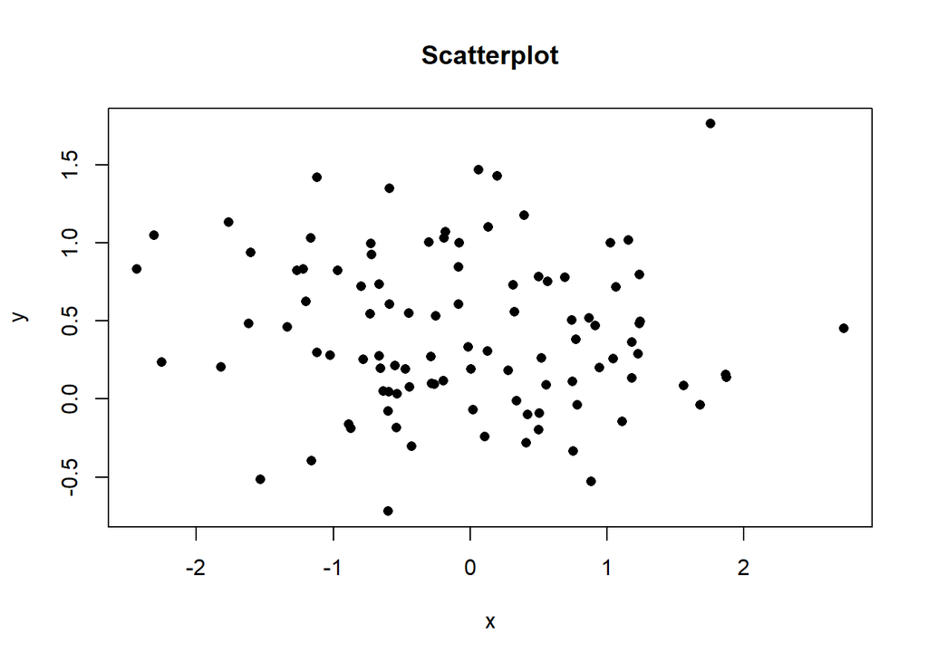

```r
x <- rnorm(100)
y <- rnorm(100,0.5,0.5)
z <- rbinom(100, 20, 0.5)
## Scatterplot
plot(x,y, main = "Scatterplot", pch = 16)
```

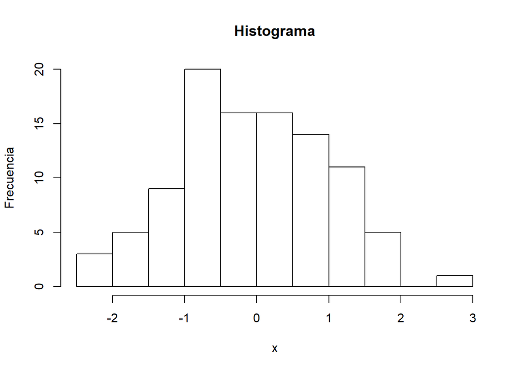

```r
## Histogram
hist(x,main = "Histograma", xlab = "x", ylab = "Frecuencia")
```

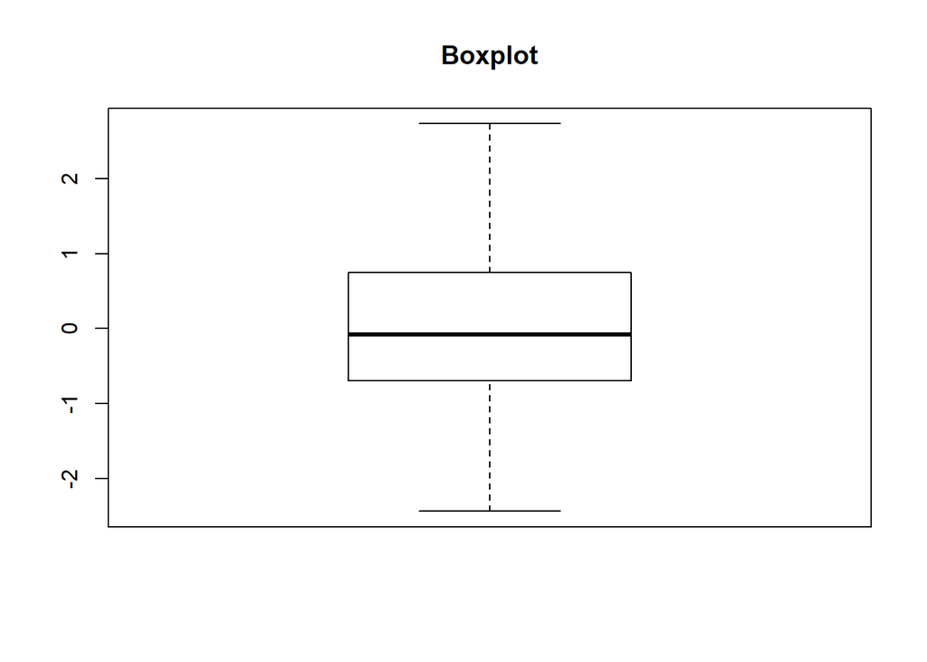

```r
## Boxplot
boxplot(x, main = "Boxplot")
```

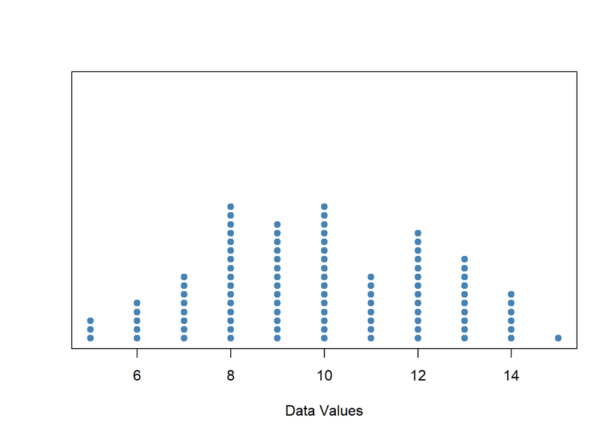

```r
## Dotplot
stripchart(z, method = "stack", offset = 0.5, at = 0, pch = 19, col = "steelblue", xlab = "Data Values")
```

## Measures of center.

The most common measures for a distribution center are:

- The **mean**, which is denoted by $\mu$ for the population and $\bar{x}$ for the sample.
- The **median**, which is denoted by $\tilde{\mu}$ for the population and $\tilde{x}$ for the sample. This (sample) statistic (a function calculated using the sample) is robust to *outliers*.
- The **mode** which is not useful for continuous distributions, and it is not always a useful measure (in fact, there is not much studies about it, since the important thing is to determine if the distribution is unimodal, bimodal, or multimodal).

## Measures of dispersion.

The most common measures for the **spread** around the center of a distirbution are

- The **range**, which is the difference between the maximum and the minimum values. Despite its easiness to be computed, it is not a reliable measure of variability.
- The **variance**, denoted by $\sigma^2$ ($s^2$) for the population (sample), is roughly speaking the average squared deviation from the mean.
- The **standard deviation**, which is the square root of the variance. Therefore, it is denoted by $\sigma$ for the population and by $s$ for the sample.
- The **interquartile range**, which is the range of the middle 50% of the data, and therefore is calculated as $IQR = Q_3 - Q_1$, where $Q_1$ and $Q_3$ are the first and third quartiles, respectively.

## Robust statistics

A **robust statistic** is a measure for which extreme values have little effect.

Let’s take a look at one example for measures of center.

```r
x <- c(1,2,3,4,5,6)
mean(x)
```

```
## [1] 3.5
```

```r
median(x)
```

```
## [1] 3.5
```

```r
y <- c(1,2,3,4,5,1000)
mean(y)
```

```
## [1] 169.1667
```

```r
median(y)
```

```
## [1] 3.5
```

And now is the turn for measures of dispersion.

```r
x <- c(1,2,3,4,5,6)
sd(x)
```

```
## [1] 1.870829
```

```r
IQR(x)
```

```
## [1] 2.5
```

```r
y <- c(1,2,3,4,5,1000)
sd(y)
```

```
## [1] 407.026
```

```r
IQR(y)
```

```
## [1] 2.5
```

## Data transformations

Sometimes, it is necessary to make some transformations to the data in order to making it *easier* to model.

A **transformation** is a rescaling of the data using a function. One example of a transformation is the **log-transformation**, which is commonly used to assess right-skewed distributions (as long as the observations are positive, but if they are not, maybe adding a constant may do the latter assumption true).

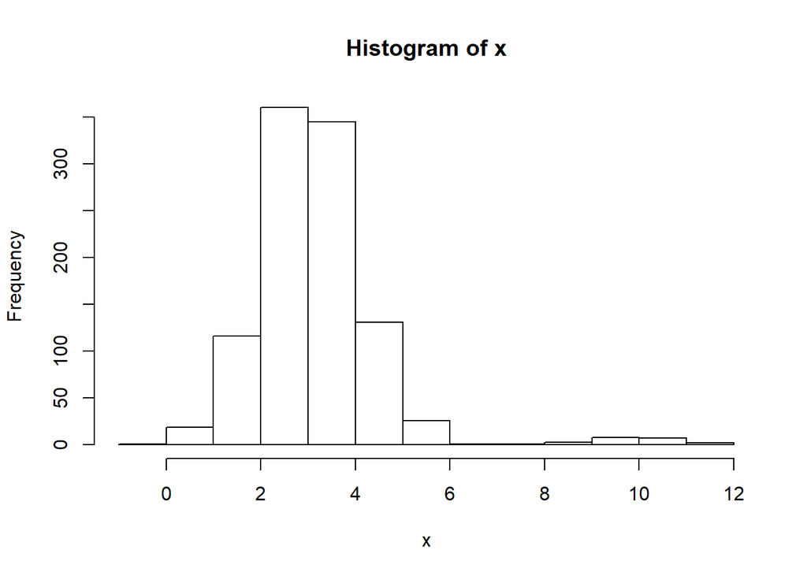

```r
x <- c(rnorm(1000,3),rnorm(20,10))
hist(x)
```

```r
y <- log(x)
```

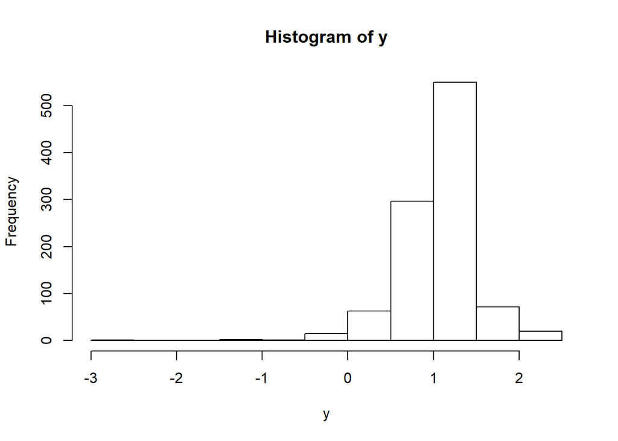

```r
hist(y)
```

Other commonly used transformations include the **square root** and the **inverse** functions.

Remember that data transformation is used, for instance,

- to see the data structure differently.
- to reduce skew, and assist the modeling process.
- to straighten non-linear relationships in scatterplots, so we can model the relationship with **simpler** methods.

# Exploring Categorical Data and introduction to Inference.

## (Summary).

The distribution of a categorical variable can be studied using **frequency tables** and **bar plots**.

Concerning the relationship between two categorical variables, **contingency tables** and **segmented bar plots** or **mosaic plots** are often used to assess it.

Finally, the relationship between a numerical and a categorical variable can be assessed by the **side-by-side** boxplots.

## Exploring Categorical Variables.

Consider to have a single categorical variable. The **frequency table** is a table with the name of the category (sometimes called levels) and the appeareance frequency in the data set. A **barplot** is a plot of the frequency observed for each category, using bars whose height can be the absolute (number of observations) or relative frequency (number of observations divided by the total observations).

```r
mydata <- read.csv("esperanzadevida.csv")
head(mydata)
```

```
##              WHO.region World.Bank.income.group              Country
## 1                Europe             High-income              Andorra
## 2 Eastern Mediterranean             High-income United Arab Emirates
## 3              Americas             High-income  Antigua and Barbuda
## 4       Western Pacific             High-income            Australia
## 5                Europe             High-income              Austria
## 6                Europe             High-income              Belgium
##   Display.Value
## 1            80
## 2            74
## 3            73
## 4            80
## 5            78
## 6            78
```

```r
table(mydata$WHO.region)
```

```
##
##                Africa              Americas Eastern Mediterranean
##                    46                    35                    22
##                Europe       South-East Asia       Western Pacific
##                    53                    11                    27
```

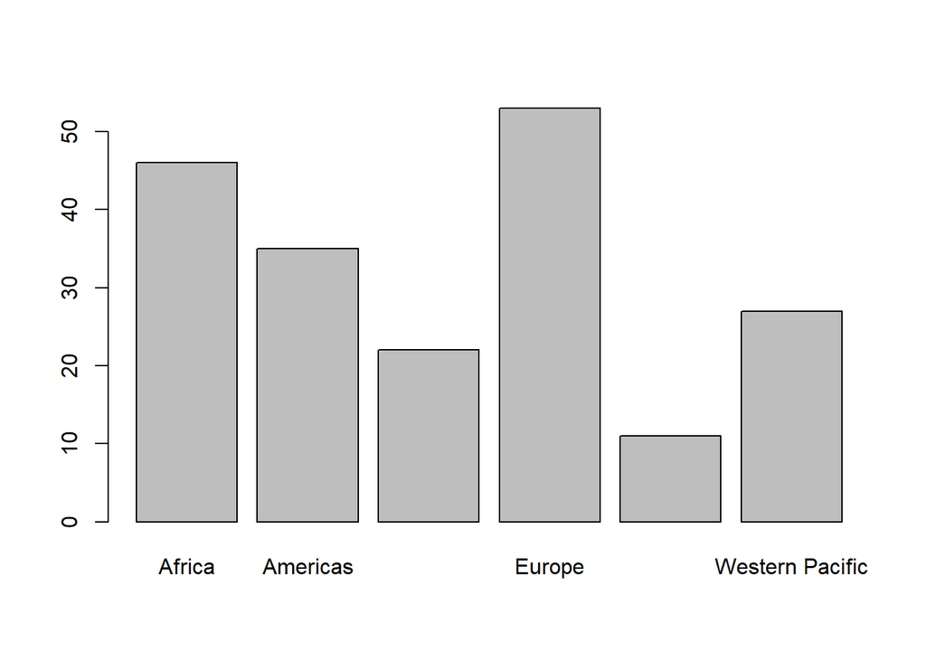

```r
barplot(table(mydata$WHO.region))
```

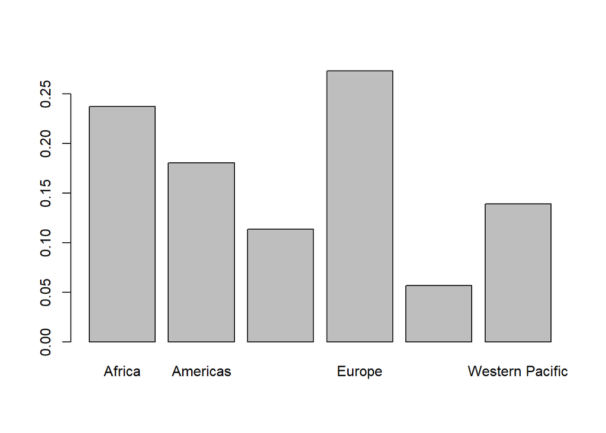

```r
barplot(table(mydata$WHO.region)/length(mydata$WHO.region))
```

```r
table(mydata$World.Bank.income.group)
```

```
##
##         High-income          Low-income Lower-middle-income Upper-middle-income
##                  51                  45                  53                  45
```

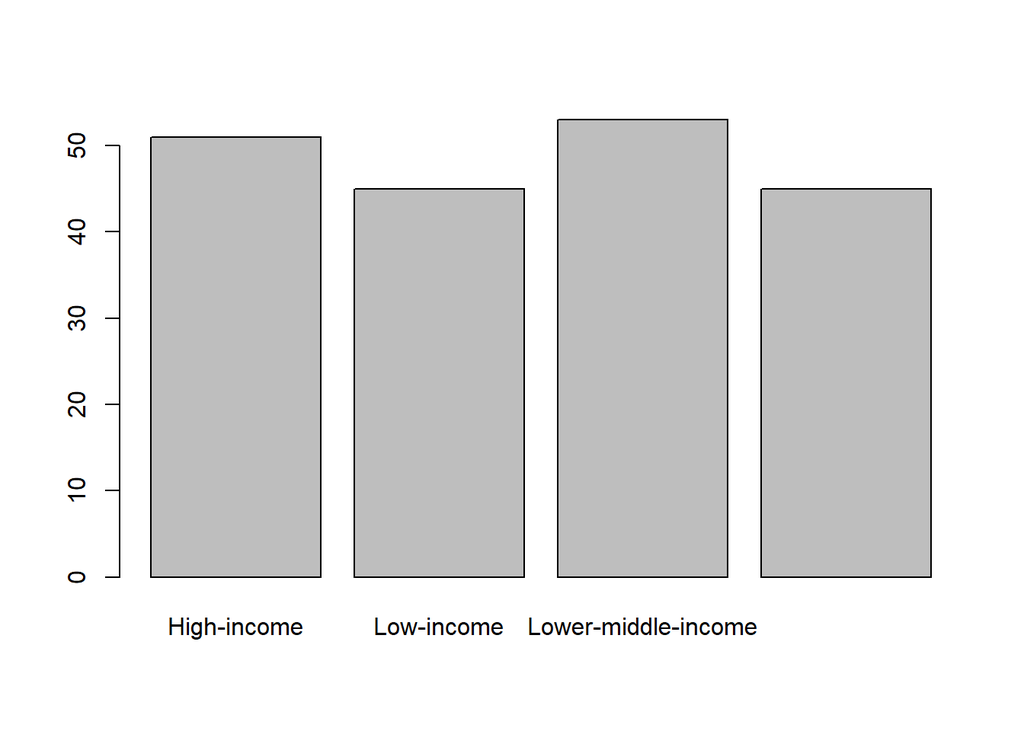

```r
barplot(table(mydata$World.Bank.income.group))
```

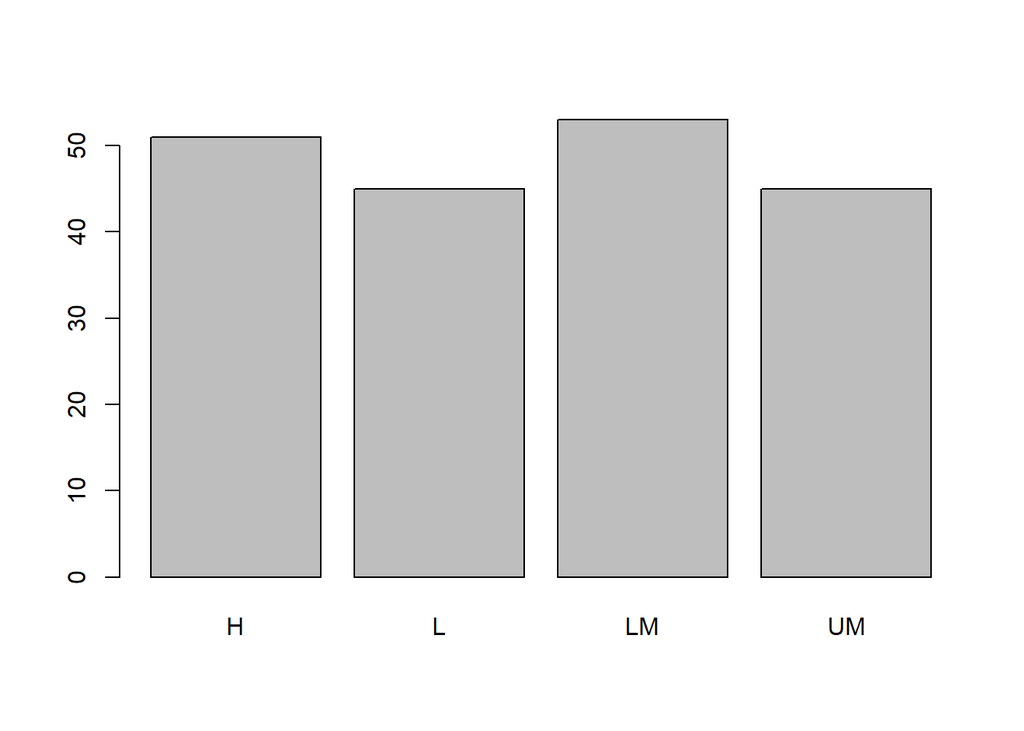

```r
barplot(table(mydata$World.Bank.income.group), names.arg = c("H", "L", "LM", "UM"))
```

Please note that barplots are usually preferred over pie charts.

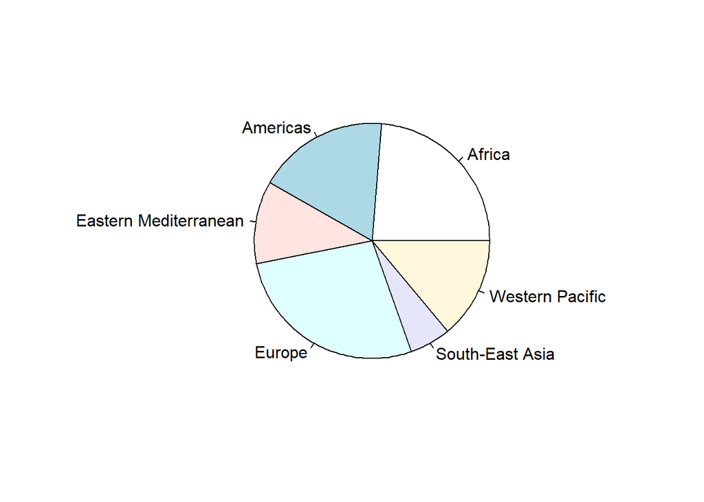

```r
pie(table(mydata$WHO.region))
```

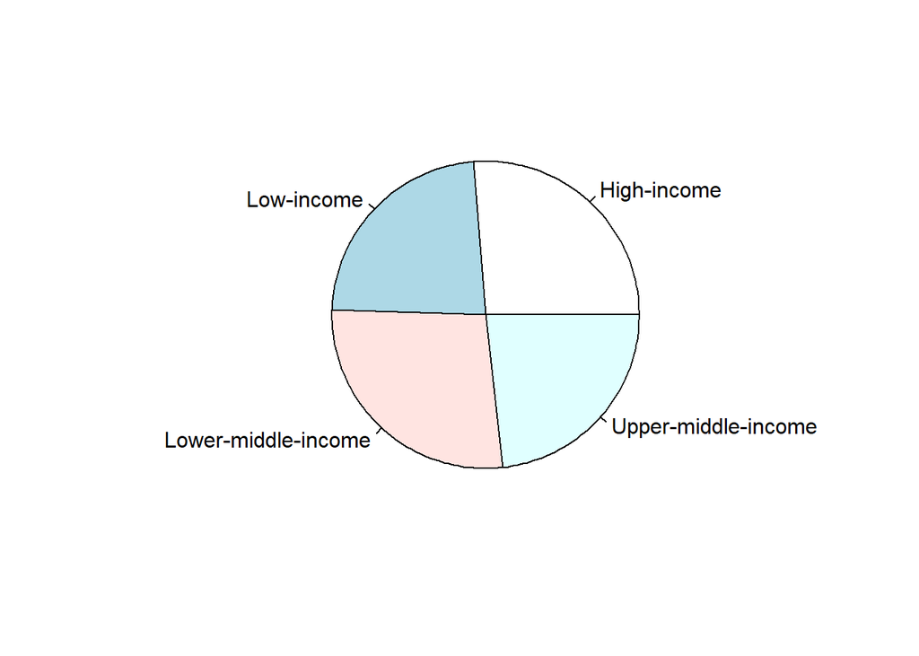

```r
pie(table(mydata$World.Bank.income.group))
```

Contingency tables are used to evaluate the relationship between two categorical variables.

```r
## Create a contingency table using data frames.
ConTable <- table(mydata$WHO.region, mydata$World.Bank.income.group)
ConTable
```

```
##
##                         High-income Low-income Lower-middle-income
##   Africa                          1         29                   9
##   Americas                        6          1                   9
##   Eastern Mediterranean           6          4                  10
##   Europe                         30          3                   7
##   South-East Asia                 0          4                   7
##   Western Pacific                 8          4                  11
##
##                         Upper-middle-income
##   Africa                                  7
##   Americas                               19
##   Eastern Mediterranean                   2
##   Europe                                 13
##   South-East Asia                         0
##   Western Pacific                         4
```

```r
## Proportions
prop.table(ConTable)
```

```
##
##                         High-income  Low-income Lower-middle-income
##   Africa                0.005154639 0.149484536         0.046391753
##   Americas              0.030927835 0.005154639         0.046391753
##   Eastern Mediterranean 0.030927835 0.020618557         0.051546392
##   Europe                0.154639175 0.015463918         0.036082474
##   South-East Asia       0.000000000 0.020618557         0.036082474
##   Western Pacific       0.041237113 0.020618557         0.056701031
##
##                         Upper-middle-income
##   Africa                        0.036082474
##   Americas                      0.097938144
##   Eastern Mediterranean         0.010309278
##   Europe                        0.067010309
##   South-East Asia               0.000000000
##   Western Pacific               0.020618557
```

```r
## Percentages
100*prop.table(ConTable)
```

```
##
##                         High-income Low-income Lower-middle-income
##   Africa                  0.5154639 14.9484536           4.6391753
##   Americas                3.0927835  0.5154639           4.6391753
##   Eastern Mediterranean   3.0927835  2.0618557           5.1546392
##   Europe                 15.4639175  1.5463918           3.6082474
##   South-East Asia         0.0000000  2.0618557           3.6082474
##   Western Pacific         4.1237113  2.0618557           5.6701031
##
##                         Upper-middle-income
##   Africa                          3.6082474
##   Americas                        9.7938144
##   Eastern Mediterranean           1.0309278
##   Europe                          6.7010309
##   South-East Asia                 0.0000000
##   Western Pacific                 2.0618557
```

```r
## It is possible to obtain the marginals from this Contingency Table (ConTable)
RowMarginals <-rowSums(ConTable)
RowMarginals
```

```
##                Africa              Americas Eastern Mediterranean
##                    46                    35                    22
##                Europe       South-East Asia       Western Pacific
##                    53                    11                    27
```

```r
ColumnMarginals <-colSums(ConTable)
ColumnMarginals
```

```
##         High-income          Low-income Lower-middle-income Upper-middle-income
##                  51                  45                  53                  45
```

```r
ConTableTotals <- cbind(ConTable, RowMarginals)
ColumnMarginals <- colSums(ConTableTotals)
ConTableTotals <- rbind(ConTableTotals, ColumnMarginals)
ConTableTotals
```

```
##                       High-income Low-income Lower-middle-income
## Africa                          1         29                   9
## Americas                        6          1                   9
## Eastern Mediterranean           6          4                  10
## Europe                         30          3                   7
## South-East Asia                 0          4                   7
## Western Pacific                 8          4                  11
## ColumnMarginals                51         45                  53
##                       Upper-middle-income RowMarginals
## Africa                                  7           46
## Americas                               19           35
## Eastern Mediterranean                   2           22
## Europe                                 13           53
## South-East Asia                         0           11
## Western Pacific                         4           27
## ColumnMarginals                        45          194
```

Is it possible to make a **segmented bar plot**. We will need the categories for each categorial variable, and the frequency or relative frequency over all the data set.

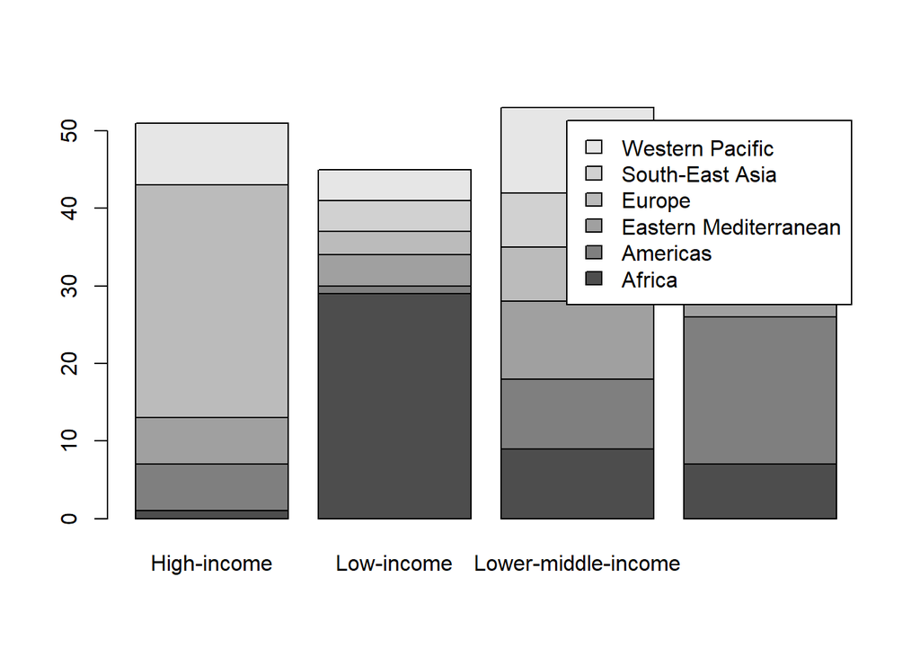

```r
## Frequency.
barplot(as.matrix(ConTable), legend = TRUE)

library(ggplot2)
```

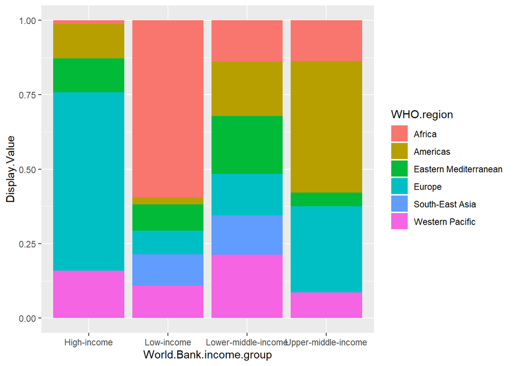

```r
ggplot(data = mydata, aes(fill=WHO.region, y=Display.Value, x=World.Bank.income.group)) +geom_bar(position="fill", stat="identity")
```

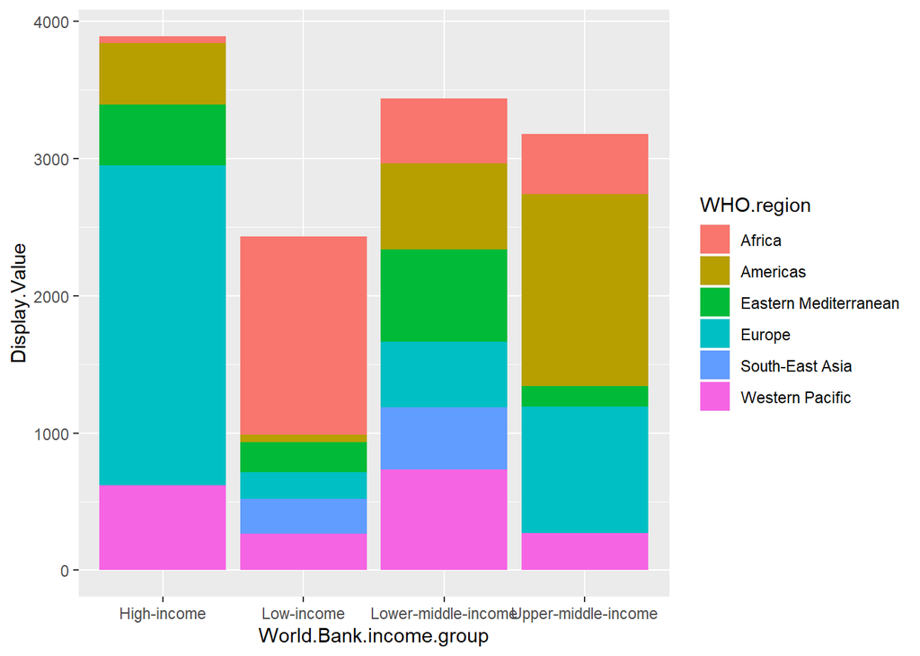

```r
ggplot(data = mydata, aes(fill=WHO.region, y=Display.Value, x=World.Bank.income.group))+geom_bar(position = "stack", stat = "identity")
```

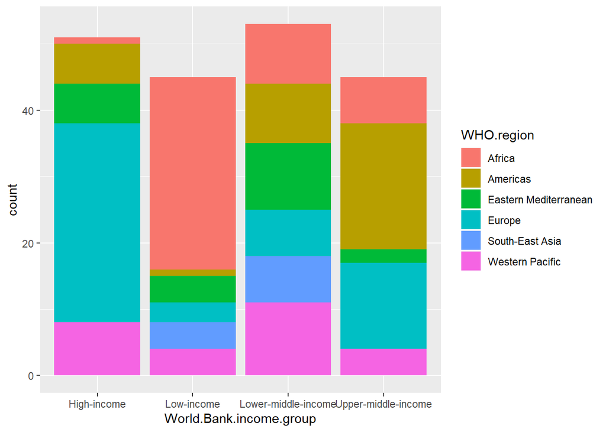

```r
newdata <- mydata
newdata$WHO.region <- factor(newdata$WHO.region)
newdata$World.Bank.income.group <- factor(newdata$World.Bank.income.group)
ggplot(data = newdata, aes(x = World.Bank.income.group, fill = WHO.region))+geom_bar()
```

Or it can be also possible to make a **mosaic plot**

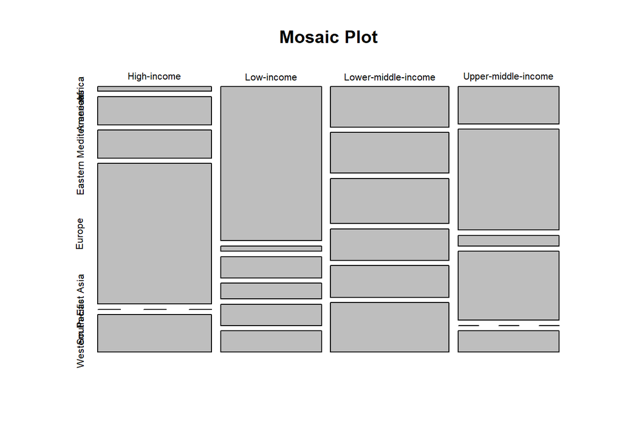

```r
mosaicplot(t(ConTable), main = "Mosaic Plot")
```

Concerning categorical and numerical variables **side-by-side boxplots** can be useful.

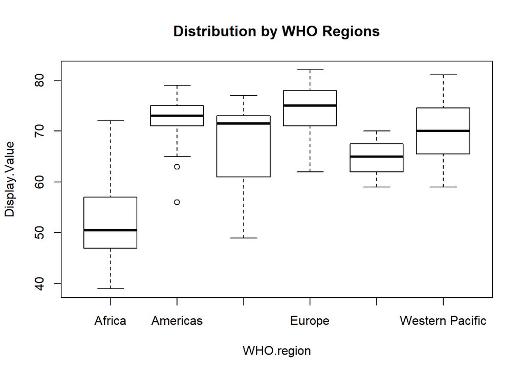

```r
boxplot(data = mydata, Display.Value ~ WHO.region, main = "Distribution by WHO Regions")
```

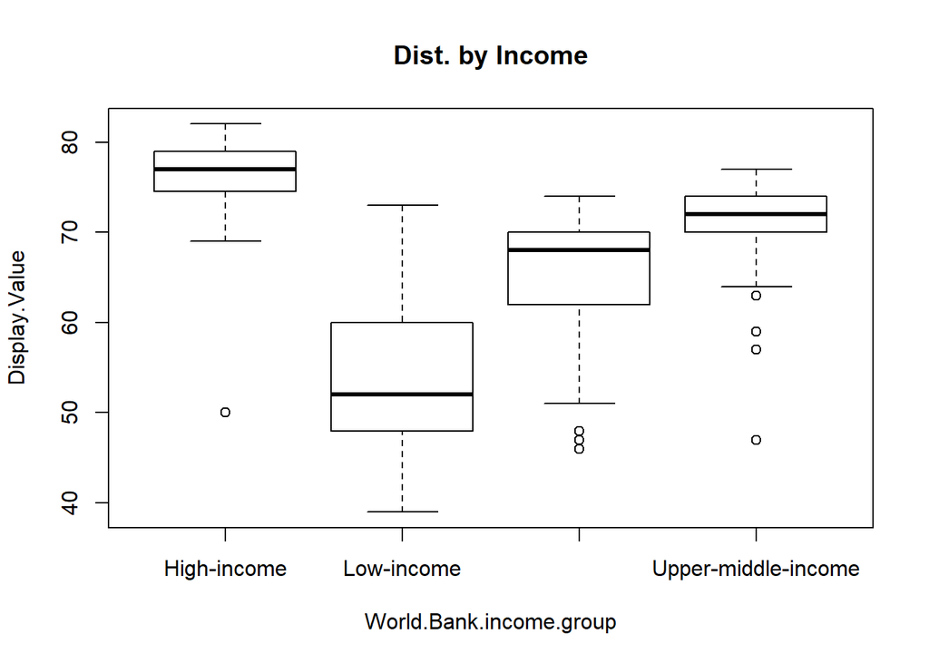

```r
boxplot(data = mydata, Display.Value ~ World.Bank.income.group, main = "Dist. by Income")
```

## Introduction to Inference.

Some interesting on-line resources are:

- [WebPage for Companion Materials for “Statistics Unlocking the power of data”](http://www.lock5stat.com/).
- [Instructor’s materials on-line](https://www2.stat.duke.edu/courses/Spring13/sta101.001/slides/unit1lec3H.pdf)